# LBGFS2024 - Problem 2: Numerator Relationship Matrix

## Required Package `pedsuite`

```r
if (!is.element("pedsuite", installed.packages()))
  install.packages("pedsuite", dependencies = TRUE)
```

## Create A complex family tree as a test

Start with a half-sib pedirgee

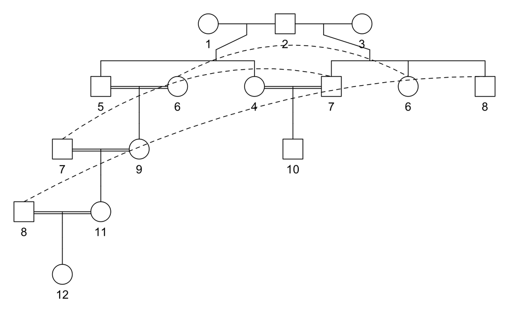

```r
library(pedtools)
ped_p2a <- halfSibPed(nch1 = 2, nch2 = 3, sex1 = 2:1, sex2 = c(2, 1, 1)) |>
  addDaughter(parents = 5:6) |>
  addSon(parents = c(4,7)) |>
  addDaughter(parents = c(7,9)) |>
  addDaughter(parents = c(8,11))
plot(ped_p2a)
```

Convert the pedigree to a tibble

```r
tbl_ped_p2a <- tibble::as.tibble(ped_p2a)
tbl_ped_p2a
```

| id | fid | mid | sex |
| --- | --- | --- | --- |
| 1 | 0 | 0 | 2 |
| 2 | 0 | 0 | 1 |
| 3 | 0 | 0 | 2 |
| 4 | 2 | 1 | 2 |
| 5 | 2 | 1 | 1 |
| 6 | 2 | 3 | 2 |
| 7 | 2 | 3 | 1 |
| 8 | 2 | 3 | 1 |
| 9 | 5 | 6 | 2 |
| 10 | 7 | 4 | 1 |

[output cut: 2 more lines]

Rename columns to

```r
tbl_ped_p2a <- dplyr::rename(tbl_ped_p2a, Animal = id, Sire = fid, Dam = mid)
tbl_ped_p2a
```

| Animal | Sire | Dam | sex |
| --- | --- | --- | --- |
| 1 | 0 | 0 | 2 |
| 2 | 0 | 0 | 1 |
| 3 | 0 | 0 | 2 |
| 4 | 2 | 1 | 2 |
| 5 | 2 | 1 | 1 |
| 6 | 2 | 3 | 2 |
| 7 | 2 | 3 | 1 |
| 8 | 2 | 3 | 1 |
| 9 | 5 | 6 | 2 |
| 10 | 7 | 4 | 1 |

[output cut: 2 more lines]

Remove founder animals

```r
library(dplyr)
tbl_ped_p2a_data <- tbl_ped_p2a %>%
  filter(Sire != "0") %>%
  filter(Dam != "0") %>%
  select(Animal, Sire, Dam)
tbl_ped_p2a_data
```

| Animal | Sire | Dam |
| --- | --- | --- |
| 4 | 2 | 1 |
| 5 | 2 | 1 |
| 6 | 2 | 3 |
| 7 | 2 | 3 |
| 8 | 2 | 3 |
| 9 | 5 | 6 |
| 10 | 7 | 4 |
| 11 | 7 | 9 |
| 12 | 8 | 11 |

## Write Data To File

```r
s_ped_p2_data <- here::here("docs", "data", "exam_pedigree_p2.csv")
readr::write_delim(tbl_ped_p2a_data, s_ped_p2_data, delim = ",")
```

## Random Pedigree

For problem 2b, we use a random pedigree.

```r
ped_p2b <- pedtools::randomPed(11, founders = 4, seed = params$seed)
ped_p2b
```

| id | fid | mid | sex |
| --- | --- | --- | --- |
| 1 | * | * | 1 |
| 2 | * | * | 1 |
| 3 | * | * | 2 |
| 4 | * | * | 1 |
| 5 | 2 | 3 | 2 |
| 6 | 1 | 3 | 2 |
| 7 | 4 | 5 | 1 |
| 8 | 1 | 5 | 1 |
| 9 | 2 | 6 | 1 |
| 10 | 7 | 5 | 1 |

[output cut: 1 more lines]

Show the graphical presentation

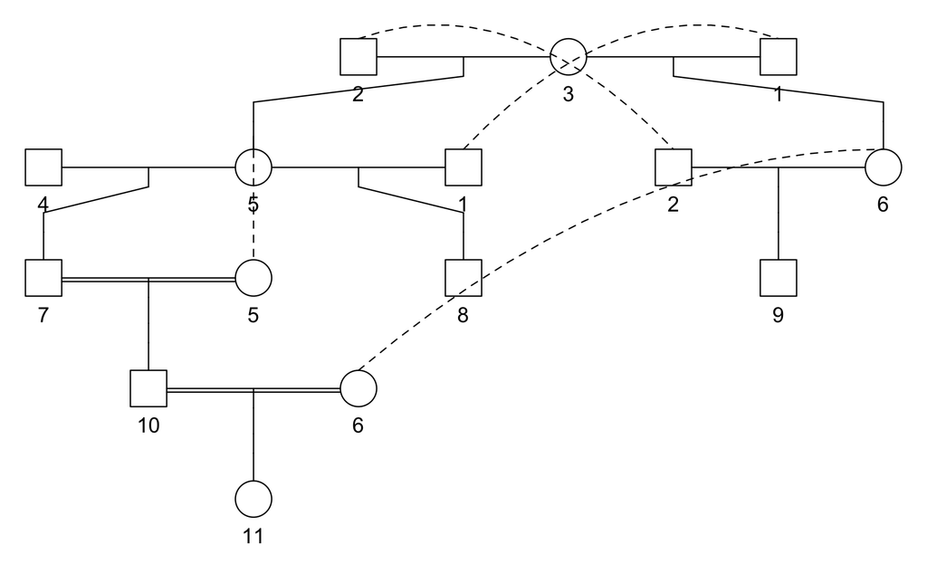

```r
plot(ped_p2b)
```

Change unknown parents from “*” to NA

```r
# change "*" for unknown parents
tbl_ped_p2b <- tibble::as.tibble(ped_p2b)
tbl_ped_p2b$fid[tbl_ped_p2b$fid == "0"] <- NA
tbl_ped_p2b$mid[tbl_ped_p2b$mid == "0"] <- NA
print(tbl_ped_p2b, n = nrow(tbl_ped_p2b))
```

| id | fid | mid | sex |
| --- | --- | --- | --- |
| 1 | NA | NA | 1 |
| 2 | NA | NA | 1 |
| 3 | NA | NA | 2 |
| 4 | NA | NA | 1 |
| 5 | 2 | 3 | 2 |
| 6 | 1 | 3 | 2 |
| 7 | 4 | 5 | 1 |
| 8 | 1 | 5 | 1 |
| 9 | 2 | 6 | 1 |
| 10 | 7 | 5 | 1 |

[output cut: 1 more lines]

Get inverse of $A$

```r
pem_p2b <- pedigreemm::pedigree(sire = as.integer(tbl_ped_p2b$fid),
                               dam = as.integer(tbl_ped_p2b$mid),
                               label = tbl_ped_p2b$id)
mat_A_inv <- pedigreemm::getAInv(pem_p2b)
mat_A_inv
```

```
11 x 11 Matrix of class "dgeMatrix"
      1    2    3    4    5          6    7  8  9         10        11
1   2.0  0.0  0.5  0.0  0.5 -1.0000000  0.0 -1  0  0.0000000  0.000000
2   0.0  2.0  0.5  0.0 -1.0  0.5000000  0.0  0 -1  0.0000000  0.000000
3   0.5  0.5  2.0  0.0 -1.0 -1.0000000  0.0  0  0  0.0000000  0.000000
4   0.0  0.0  0.0  1.5  0.5  0.0000000 -1.0  0  0  0.0000000  0.000000
5   0.5 -1.0 -1.0  0.5  3.5  0.0000000 -0.5 -1  0 -1.0000000  0.000000
6  -1.0  0.5 -1.0  0.0  0.0  3.0714286  0.0  0 -1  0.5714286 -1.142857
7   0.0  0.0  0.0 -1.0 -0.5  0.0000000  2.5  0  0 -1.0000000  0.000000
8  -1.0  0.0  0.0  0.0 -1.0  0.0000000  0.0  2  0  0.0000000  0.000000
9   0.0 -1.0  0.0  0.0  0.0 -1.0000000  0.0  0  2  0.0000000  0.000000
10  0.0  0.0  0.0  0.0 -1.0  0.5714286 -1.0  0  0  2.5714286 -1.142857
11  0.0  0.0  0.0  0.0  0.0 -1.1428571  0.0  0  0 -1.1428571  2.285714
```

## Write Matrix To File

```r
tbl_mat_A_inv <- tibble::as.tibble(as.matrix(mat_A_inv))
s_mat_p2 <- here::here("docs", "data", "exam_inv_num_rel_mat_p2.csv")
readr::write_delim(tbl_mat_A_inv, s_mat_p2, delim = ",")
```

## Matrix Decomposition of $A$

The cholesky decomposition of $A$ is given by

$$A = R\cdot R^T$$
where $R$ is a lower diagonal matrix. This can be obtained with

```r
mat_A <- as.matrix(pedigreemm::getA(pem_p2b))
mat_R <- t(chol(mat_A))
mat_R
```

```
      1      2      3     4         5         6            7             8            9        10        11
1  1.00 0.0000 0.0000 0.000 0.0000000 0.0000000 0.000000e+00  0.000000e+00 0.000000e+00 0.0000000 0.0000000
2  0.00 1.0000 0.0000 0.000 0.0000000 0.0000000 0.000000e+00  0.000000e+00 0.000000e+00 0.0000000 0.0000000
3  0.00 0.0000 1.0000 0.000 0.0000000 0.0000000 0.000000e+00  0.000000e+00 0.000000e+00 0.0000000 0.0000000
4  0.00 0.0000 0.0000 1.000 0.0000000 0.0000000 0.000000e+00  0.000000e+00 0.000000e+00 0.0000000 0.0000000
5  0.00 0.5000 0.5000 0.000 0.7071068 0.0000000 0.000000e+00  0.000000e+00 0.000000e+00 0.0000000 0.0000000
6  0.50 0.0000 0.5000 0.000 0.0000000 0.7071068 0.000000e+00  0.000000e+00 0.000000e+00 0.0000000 0.0000000
7  0.00 0.2500 0.2500 0.500 0.3535534 0.0000000 7.071068e-01  0.000000e+00 0.000000e+00 0.0000000 0.0000000
8  0.50 0.2500 0.2500 0.000 0.3535534 0.0000000 3.925231e-17  7.071068e-01 0.000000e+00 0.0000000 0.0000000
9  0.25 0.5000 0.2500 0.000 0.0000000 0.3535534 0.000000e+00  0.000000e+00 7.071068e-01 0.0000000 0.0000000
10 0.00 0.3750 0.3750 0.250 0.5303301 0.0000000 3.535534e-01  5.887847e-17 0.000000e+00 0.7071068 0.0000000
11 0.25 0.1875 0.4375 0.125 0.2651650 0.3535534 1.767767e-01 -9.813078e-18 3.925231e-17 0.3535534 0.6614378
```

Check

```r
round(mat_R %*% t(mat_R) - mat_A, digits = 8)
```

```
   1 2 3 4 5 6 7 8 9 10 11
1  0 0 0 0 0 0 0 0 0  0  0
2  0 0 0 0 0 0 0 0 0  0  0
3  0 0 0 0 0 0 0 0 0  0  0
4  0 0 0 0 0 0 0 0 0  0  0
5  0 0 0 0 0 0 0 0 0  0  0
6  0 0 0 0 0 0 0 0 0  0  0
7  0 0 0 0 0 0 0 0 0  0  0
8  0 0 0 0 0 0 0 0 0  0  0
9  0 0 0 0 0 0 0 0 0  0  0
10 0 0 0 0 0 0 0 0 0  0  0
11 0 0 0 0 0 0 0 0 0  0  0
```

The matrix $R$ can be decomposed into

$$R = L\cdot S$$
where $L$ is a lower triangular matrix with a diagonal of all ones and $S$ is the diagonal matrix with diagonal elements which are the same as the matrix $R$. Hence $S$ is obtained by

```r
mat_S <- diag(diag(mat_R), nrow = nrow(mat_R))
mat_S
```

```
      [,1] [,2] [,3] [,4]      [,5]      [,6]      [,7]      [,8]      [,9]     [,10]     [,11]
 [1,]    1    0    0    0 0.0000000 0.0000000 0.0000000 0.0000000 0.0000000 0.0000000 0.0000000
 [2,]    0    1    0    0 0.0000000 0.0000000 0.0000000 0.0000000 0.0000000 0.0000000 0.0000000
 [3,]    0    0    1    0 0.0000000 0.0000000 0.0000000 0.0000000 0.0000000 0.0000000 0.0000000
 [4,]    0    0    0    1 0.0000000 0.0000000 0.0000000 0.0000000 0.0000000 0.0000000 0.0000000
 [5,]    0    0    0    0 0.7071068 0.0000000 0.0000000 0.0000000 0.0000000 0.0000000 0.0000000
 [6,]    0    0    0    0 0.0000000 0.7071068 0.0000000 0.0000000 0.0000000 0.0000000 0.0000000
 [7,]    0    0    0    0 0.0000000 0.0000000 0.7071068 0.0000000 0.0000000 0.0000000 0.0000000
 [8,]    0    0    0    0 0.0000000 0.0000000 0.0000000 0.7071068 0.0000000 0.0000000 0.0000000
 [9,]    0    0    0    0 0.0000000 0.0000000 0.0000000 0.0000000 0.7071068 0.0000000 0.0000000
[10,]    0    0    0    0 0.0000000 0.0000000 0.0000000 0.0000000 0.0000000 0.7071068 0.0000000
[11,]    0    0    0    0 0.0000000 0.0000000 0.0000000 0.0000000 0.0000000 0.0000000 0.6614378
```

Matrix $L$ can be computed as

$$L = R \cdot S^{-1}$$

```r
mat_L = mat_R %*% solve(mat_S)
mat_L
```

```
   [,1]   [,2]   [,3]  [,4]  [,5] [,6]         [,7]          [,8]         [,9] [,10] [,11]
1  1.00 0.0000 0.0000 0.000 0.000  0.0 0.000000e+00  0.000000e+00 0.000000e+00   0.0     0
2  0.00 1.0000 0.0000 0.000 0.000  0.0 0.000000e+00  0.000000e+00 0.000000e+00   0.0     0
3  0.00 0.0000 1.0000 0.000 0.000  0.0 0.000000e+00  0.000000e+00 0.000000e+00   0.0     0
4  0.00 0.0000 0.0000 1.000 0.000  0.0 0.000000e+00  0.000000e+00 0.000000e+00   0.0     0
5  0.00 0.5000 0.5000 0.000 1.000  0.0 0.000000e+00  0.000000e+00 0.000000e+00   0.0     0
6  0.50 0.0000 0.5000 0.000 0.000  1.0 0.000000e+00  0.000000e+00 0.000000e+00   0.0     0
7  0.00 0.2500 0.2500 0.500 0.500  0.0 1.000000e+00  0.000000e+00 0.000000e+00   0.0     0
8  0.50 0.2500 0.2500 0.000 0.500  0.0 5.551115e-17  1.000000e+00 0.000000e+00   0.0     0
9  0.25 0.5000 0.2500 0.000 0.000  0.5 0.000000e+00  0.000000e+00 1.000000e+00   0.0     0
10 0.00 0.3750 0.3750 0.250 0.750  0.0 5.000000e-01  8.326673e-17 0.000000e+00   1.0     0
11 0.25 0.1875 0.4375 0.125 0.375  0.5 2.500000e-01 -1.387779e-17 5.551115e-17   0.5     1
```

The matrix $P$ is obtained as $P = I - L^{-1}$

```r
mat_P <- diag(nrow = nrow(mat_L)) - solve(mat_L)
round(mat_P, digits = 6)
```

```
        1   2   3   4   5   6   7 8 9  10 11
 [1,] 0.0 0.0 0.0 0.0 0.0 0.0 0.0 0 0 0.0  0
 [2,] 0.0 0.0 0.0 0.0 0.0 0.0 0.0 0 0 0.0  0
 [3,] 0.0 0.0 0.0 0.0 0.0 0.0 0.0 0 0 0.0  0
 [4,] 0.0 0.0 0.0 0.0 0.0 0.0 0.0 0 0 0.0  0
 [5,] 0.0 0.5 0.5 0.0 0.0 0.0 0.0 0 0 0.0  0
 [6,] 0.5 0.0 0.5 0.0 0.0 0.0 0.0 0 0 0.0  0
 [7,] 0.0 0.0 0.0 0.5 0.5 0.0 0.0 0 0 0.0  0
 [8,] 0.5 0.0 0.0 0.0 0.5 0.0 0.0 0 0 0.0  0
 [9,] 0.0 0.5 0.0 0.0 0.0 0.5 0.0 0 0 0.0  0
[10,] 0.0 0.0 0.0 0.0 0.5 0.0 0.5 0 0 0.0  0
[11,] 0.0 0.0 0.0 0.0 0.0 0.5 0.0 0 0 0.5  0
```

### Port to $A^{-1}$

Solution via decomposition of $A^{-1}$ does not work. The following sections show why.

Based on the cholesky decomposition of $A = R \cdot R^T$, we get

$$A^{-1} = (R^T)^{-1} \cdot
R^{-1}$$

which is a valid decomposition, but it is not a cholesky decomposition, because $(R^T)^{-1}$ is not a lower triangular matrix.

This leads to the relationship between matrices $Q$ and $R$ as

$$Q \ne (R^T)^{-1} =
(R^{-1})^T$$

```r
mat_A_inv <- as.matrix(pedigreemm::getAInv(pem_p2b))
mat_A_inv
```

```
      1    2    3    4    5          6    7  8  9         10        11
1   2.0  0.0  0.5  0.0  0.5 -1.0000000  0.0 -1  0  0.0000000  0.000000
2   0.0  2.0  0.5  0.0 -1.0  0.5000000  0.0  0 -1  0.0000000  0.000000
3   0.5  0.5  2.0  0.0 -1.0 -1.0000000  0.0  0  0  0.0000000  0.000000
4   0.0  0.0  0.0  1.5  0.5  0.0000000 -1.0  0  0  0.0000000  0.000000
5   0.5 -1.0 -1.0  0.5  3.5  0.0000000 -0.5 -1  0 -1.0000000  0.000000
6  -1.0  0.5 -1.0  0.0  0.0  3.0714286  0.0  0 -1  0.5714286 -1.142857
7   0.0  0.0  0.0 -1.0 -0.5  0.0000000  2.5  0  0 -1.0000000  0.000000
8  -1.0  0.0  0.0  0.0 -1.0  0.0000000  0.0  2  0  0.0000000  0.000000
9   0.0 -1.0  0.0  0.0  0.0 -1.0000000  0.0  0  2  0.0000000  0.000000
10  0.0  0.0  0.0  0.0 -1.0  0.5714286 -1.0  0  0  2.5714286 -1.142857
11  0.0  0.0  0.0  0.0  0.0 -1.1428571  0.0  0  0 -1.1428571  2.285714
```

The cholesky decomposition factor $Q$ of $A^{-1}$ is then

```r
mat_Q <- t(chol(mat_A_inv))
mat_Q
```

```
            1          2          3          4           5           6            7          8           9         10
1   1.4142136  0.0000000  0.0000000  0.0000000  0.00000000  0.00000000  0.000000000  0.0000000  0.00000000  0.0000000
2   0.0000000  1.4142136  0.0000000  0.0000000  0.00000000  0.00000000  0.000000000  0.0000000  0.00000000  0.0000000
3   0.3535534  0.3535534  1.3228757  0.0000000  0.00000000  0.00000000  0.000000000  0.0000000  0.00000000  0.0000000
4   0.0000000  0.0000000  0.0000000  1.2247449  0.00000000  0.00000000  0.000000000  0.0000000  0.00000000  0.0000000
5   0.3535534 -0.7071068 -0.6614378  0.4082483  1.50692844  0.00000000  0.000000000  0.0000000  0.00000000  0.0000000
6  -0.7071068  0.3535534 -0.6614378  0.0000000  0.04147509  1.41675982  0.000000000  0.0000000  0.00000000  0.0000000
7   0.0000000  0.0000000  0.0000000 -0.8164966 -0.11060025  0.00323778  1.349477838  0.0000000  0.00000000  0.0000000
8  -0.7071068  0.0000000  0.1889822  0.0000000 -0.41475095 -0.25254680 -0.033386149  1.1078686  0.00000000  0.0000000
9   0.0000000 -0.7071068  0.1889822  0.0000000 -0.24885057 -0.43386246 -0.019354290 -0.2248841  1.07850592  0.0000000
10  0.0000000  0.0000000  0.0000000  0.0000000 -0.66360152  0.42276150 -0.796429014 -0.1760606 -0.03405156  1.1339657
11  0.0000000  0.0000000  0.0000000  0.0000000  0.00000000 -0.80666965  0.001935429 -0.1838280 -0.36280394 -0.7451775
          11
1  0.0000000
2  0.0000000
3  0.0000000
4  0.0000000
5  0.0000000
6  0.0000000
7  0.0000000
8  0.0000000
9  0.0000000
10 0.0000000
11 0.9561829
```

which is clearly lower triangular. The following shows that $(R^T)^{-1}$ is upper triangular and hence cannot be equal to $Q$.

```r
solve(t(mat_R))
```

```
      1             2             3             4             5             6             7             8             9            10
 [1,] 1 -5.947623e-18 -1.110223e-16 -3.269499e-18  8.271023e-17 -7.071068e-01 -9.581889e-17 -7.071068e-01 -5.130555e-17 -2.845793e-16
 [2,] 0  1.000000e+00 -5.551115e-17  1.023134e-17 -7.071068e-01  1.612149e-16 -6.274580e-17  1.110223e-16 -7.071068e-01  5.551115e-17
 [3,] 0  0.000000e+00  1.000000e+00  3.283373e-19 -7.071068e-01 -7.071068e-01 -1.112545e-16 -5.551115e-17 -1.668223e-16 -2.220446e-16
 [4,] 0  0.000000e+00  0.000000e+00  1.000000e+00 -7.466822e-18 -2.408849e-17 -7.071068e-01 -1.023609e-16 -6.926010e-19  5.924456e-17
 [5,] 0  0.000000e+00  0.000000e+00  0.000000e+00  1.414214e+00 -4.710277e-16 -7.071068e-01 -7.071068e-01  2.551400e-16 -7.071068e-01
 [6,] 0  0.000000e+00  0.000000e+00  0.000000e+00  0.000000e+00  1.414214e+00  7.850462e-17  3.140185e-16 -7.071068e-01  5.397193e-16
 [7,] 0  0.000000e+00  0.000000e+00  0.000000e+00  0.000000e+00  0.000000e+00  1.414214e+00  3.140185e-16 -3.925231e-17 -7.071068e-01
 [8,] 0  0.000000e+00  0.000000e+00  0.000000e+00  0.000000e+00  0.000000e+00  0.000000e+00  1.414214e+00  3.486306e-32  1.743153e-32
 [9,] 0  0.000000e+00  0.000000e+00  0.000000e+00  0.000000e+00  0.000000e+00  0.000000e+00  0.000000e+00  1.414214e+00 -2.158877e-16
[10,] 0  0.000000e+00  0.000000e+00  0.000000e+00  0.000000e+00  0.000000e+00  0.000000e+00  0.000000e+00  0.000000e+00  1.414214e+00
[11,] 0  0.000000e+00  0.000000e+00  0.000000e+00  0.000000e+00  0.000000e+00  0.000000e+00  0.000000e+00  0.000000e+00  0.000000e+00
                 11
 [1,]  1.665335e-16
 [2,] -3.569203e-17
 [3,] -1.522190e-16
 [4,] -4.133681e-17
 [5,]  1.094908e-16
 [6,] -7.559289e-01
 [7,]  3.575672e-16
 [8,] -8.392497e-17
 [9,]  3.147186e-17
[10,] -7.559289e-01
[11,]  1.511858e+00
```

Check

```r
round(mat_Q %*% t(mat_Q) - mat_A_inv, digits = 8)
```

```
   1 2 3 4 5 6 7 8 9 10 11
1  0 0 0 0 0 0 0 0 0  0  0
2  0 0 0 0 0 0 0 0 0  0  0
3  0 0 0 0 0 0 0 0 0  0  0
4  0 0 0 0 0 0 0 0 0  0  0
5  0 0 0 0 0 0 0 0 0  0  0
6  0 0 0 0 0 0 0 0 0  0  0
7  0 0 0 0 0 0 0 0 0  0  0
8  0 0 0 0 0 0 0 0 0  0  0
9  0 0 0 0 0 0 0 0 0  0  0
10 0 0 0 0 0 0 0 0 0  0  0
11 0 0 0 0 0 0 0 0 0  0  0
```

```r
round(solve(t(mat_R)) %*% solve(mat_R) - mat_A_inv, digits = 8)
```

```
   1 2 3 4 5 6 7 8 9 10 11
1  0 0 0 0 0 0 0 0 0  0  0
2  0 0 0 0 0 0 0 0 0  0  0
3  0 0 0 0 0 0 0 0 0  0  0
4  0 0 0 0 0 0 0 0 0  0  0
5  0 0 0 0 0 0 0 0 0  0  0
6  0 0 0 0 0 0 0 0 0  0  0
7  0 0 0 0 0 0 0 0 0  0  0
8  0 0 0 0 0 0 0 0 0  0  0
9  0 0 0 0 0 0 0 0 0  0  0
10 0 0 0 0 0 0 0 0 0  0  0
11 0 0 0 0 0 0 0 0 0  0  0
```

```r
round(mat_Q - solve(t(mat_R)), digits = 8)
```

```
            1          2          3          4           5           6           7          8           9         10
1   0.4142136  0.0000000  0.0000000  0.0000000  0.00000000  0.70710678  0.00000000  0.7071068  0.00000000  0.0000000
2   0.0000000  0.4142136  0.0000000  0.0000000  0.70710678  0.00000000  0.00000000  0.0000000  0.70710678  0.0000000
3   0.3535534  0.3535534  0.3228757  0.0000000  0.70710678  0.70710678  0.00000000  0.0000000  0.00000000  0.0000000
4   0.0000000  0.0000000  0.0000000  0.2247449  0.00000000  0.00000000  0.70710678  0.0000000  0.00000000  0.0000000
5   0.3535534 -0.7071068 -0.6614378  0.4082483  0.09271488  0.00000000  0.70710678  0.7071068  0.00000000  0.7071068
6  -0.7071068  0.3535534 -0.6614378  0.0000000  0.04147509  0.00254626  0.00000000  0.0000000  0.70710678  0.0000000
7   0.0000000  0.0000000  0.0000000 -0.8164966 -0.11060025  0.00323778 -0.06473572  0.0000000  0.00000000  0.7071068
8  -0.7071068  0.0000000  0.1889822  0.0000000 -0.41475095 -0.25254680 -0.03338615 -0.3063450  0.00000000  0.0000000
9   0.0000000 -0.7071068  0.1889822  0.0000000 -0.24885057 -0.43386246 -0.01935429 -0.2248841 -0.33570764  0.0000000
10  0.0000000  0.0000000  0.0000000  0.0000000 -0.66360152  0.42276150 -0.79642901 -0.1760606 -0.03405156 -0.2802478
11  0.0000000  0.0000000  0.0000000  0.0000000  0.00000000 -0.80666965  0.00193543 -0.1838280 -0.36280394 -0.7451775
          11
1   0.000000
2   0.000000
3   0.000000
4   0.000000
5   0.000000
6   0.755929
7   0.000000
8   0.000000
9   0.000000
10  0.755929
11 -0.555675
```

```r
round(mat_Q - solve(mat_R), digits = 8)
```

```
           1         2          3          4           5           6           7          8           9          10
1  0.4142136 0.0000000 0.00000000  0.0000000  0.00000000  0.00000000  0.00000000  0.0000000  0.00000000  0.00000000
2  0.0000000 0.4142136 0.00000000  0.0000000  0.00000000  0.00000000  0.00000000  0.0000000  0.00000000  0.00000000
3  0.3535534 0.3535534 0.32287566  0.0000000  0.00000000  0.00000000  0.00000000  0.0000000  0.00000000  0.00000000
4  0.0000000 0.0000000 0.00000000  0.2247449  0.00000000  0.00000000  0.00000000  0.0000000  0.00000000  0.00000000
5  0.3535534 0.0000000 0.04566895  0.4082483  0.09271488  0.00000000  0.00000000  0.0000000  0.00000000  0.00000000
6  0.0000000 0.3535534 0.04566895  0.0000000  0.04147509  0.00254626  0.00000000  0.0000000  0.00000000  0.00000000
7  0.0000000 0.0000000 0.00000000 -0.1093898  0.59650653  0.00323778 -0.06473572  0.0000000  0.00000000  0.00000000
8  0.0000000 0.0000000 0.18898224  0.0000000  0.29235583 -0.25254680 -0.03338615 -0.3063450  0.00000000  0.00000000
9  0.0000000 0.0000000 0.18898224  0.0000000 -0.24885057  0.27324432 -0.01935429 -0.2248841 -0.33570764  0.00000000
10 0.0000000 0.0000000 0.00000000  0.0000000  0.04350526  0.42276150 -0.08932223 -0.1760606 -0.03405156 -0.28024782
11 0.0000000 0.0000000 0.00000000  0.0000000  0.00000000 -0.05074070  0.00193543 -0.1838280 -0.36280394  0.01075146
          11
1   0.000000
2   0.000000
3   0.000000
4   0.000000
5   0.000000
6   0.000000
7   0.000000
8   0.000000
9   0.000000
10  0.000000
11 -0.555675
```

Decomposition of $Q$ into

```r
mat_S_inv <- diag(diag(mat_Q), nrow = nrow(mat_Q))
mat_S_inv
```

```
          [,1]     [,2]     [,3]     [,4]     [,5]    [,6]     [,7]     [,8]     [,9]    [,10]     [,11]
 [1,] 1.414214 0.000000 0.000000 0.000000 0.000000 0.00000 0.000000 0.000000 0.000000 0.000000 0.0000000
 [2,] 0.000000 1.414214 0.000000 0.000000 0.000000 0.00000 0.000000 0.000000 0.000000 0.000000 0.0000000
 [3,] 0.000000 0.000000 1.322876 0.000000 0.000000 0.00000 0.000000 0.000000 0.000000 0.000000 0.0000000
 [4,] 0.000000 0.000000 0.000000 1.224745 0.000000 0.00000 0.000000 0.000000 0.000000 0.000000 0.0000000
 [5,] 0.000000 0.000000 0.000000 0.000000 1.506928 0.00000 0.000000 0.000000 0.000000 0.000000 0.0000000
 [6,] 0.000000 0.000000 0.000000 0.000000 0.000000 1.41676 0.000000 0.000000 0.000000 0.000000 0.0000000
 [7,] 0.000000 0.000000 0.000000 0.000000 0.000000 0.00000 1.349478 0.000000 0.000000 0.000000 0.0000000
 [8,] 0.000000 0.000000 0.000000 0.000000 0.000000 0.00000 0.000000 1.107869 0.000000 0.000000 0.0000000
 [9,] 0.000000 0.000000 0.000000 0.000000 0.000000 0.00000 0.000000 0.000000 1.078506 0.000000 0.0000000
[10,] 0.000000 0.000000 0.000000 0.000000 0.000000 0.00000 0.000000 0.000000 0.000000 1.133966 0.0000000
[11,] 0.000000 0.000000 0.000000 0.000000 0.000000 0.00000 0.000000 0.000000 0.000000 0.000000 0.9561829
```

```r
mat_L_inv_t <- mat_Q %*% solve(mat_S_inv)
mat_L_inv_t
```

```
    [,1]  [,2]       [,3]       [,4]        [,5]         [,6]         [,7]       [,8]       [,9]      [,10] [,11]
1   1.00  0.00  0.0000000  0.0000000  0.00000000  0.000000000  0.000000000  0.0000000  0.0000000  0.0000000     0
2   0.00  1.00  0.0000000  0.0000000  0.00000000  0.000000000  0.000000000  0.0000000  0.0000000  0.0000000     0
3   0.25  0.25  1.0000000  0.0000000  0.00000000  0.000000000  0.000000000  0.0000000  0.0000000  0.0000000     0
4   0.00  0.00  0.0000000  1.0000000  0.00000000  0.000000000  0.000000000  0.0000000  0.0000000  0.0000000     0
5   0.25 -0.50 -0.5000000  0.3333333  1.00000000  0.000000000  0.000000000  0.0000000  0.0000000  0.0000000     0
6  -0.50  0.25 -0.5000000  0.0000000  0.02752294  1.000000000  0.000000000  0.0000000  0.0000000  0.0000000     0
7   0.00  0.00  0.0000000 -0.6666667 -0.07339450  0.002285341  1.000000000  0.0000000  0.0000000  0.0000000     0
8  -0.50  0.00  0.1428571  0.0000000 -0.27522936 -0.178256611 -0.024740050  1.0000000  0.0000000  0.0000000     0
9   0.00 -0.50  0.1428571  0.0000000 -0.16513761 -0.306235717 -0.014342058 -0.2029881  1.0000000  0.0000000     0
10  0.00  0.00  0.0000000  0.0000000 -0.44036697  0.298400261 -0.590175690 -0.1589183 -0.0315729  1.0000000     0
11  0.00  0.00  0.0000000  0.0000000  0.00000000 -0.569376428  0.001434206 -0.1659294 -0.3363949 -0.6571429     1
```

The cholesky decomposition is given by

$$A^{-1} = RR^T$$

A triangular matrix $R$ can be decomposed into a diagonal matrix $S$ and a triangular matrix $L$.

$$R = LS$$

The matrix $S$ is the diagonal elements of $R^T$, then $L$ is computed as

$$L = RS^{-1}$$

$$A^{-1} = LDL^T$$

```r
mat_A_inv <- as.matrix(mat_A_inv)
mat_A_inv
```

```
      1    2    3    4    5          6    7  8  9         10        11
1   2.0  0.0  0.5  0.0  0.5 -1.0000000  0.0 -1  0  0.0000000  0.000000
2   0.0  2.0  0.5  0.0 -1.0  0.5000000  0.0  0 -1  0.0000000  0.000000
3   0.5  0.5  2.0  0.0 -1.0 -1.0000000  0.0  0  0  0.0000000  0.000000
4   0.0  0.0  0.0  1.5  0.5  0.0000000 -1.0  0  0  0.0000000  0.000000
5   0.5 -1.0 -1.0  0.5  3.5  0.0000000 -0.5 -1  0 -1.0000000  0.000000
6  -1.0  0.5 -1.0  0.0  0.0  3.0714286  0.0  0 -1  0.5714286 -1.142857
7   0.0  0.0  0.0 -1.0 -0.5  0.0000000  2.5  0  0 -1.0000000  0.000000
8  -1.0  0.0  0.0  0.0 -1.0  0.0000000  0.0  2  0  0.0000000  0.000000
9   0.0 -1.0  0.0  0.0  0.0 -1.0000000  0.0  0  2  0.0000000  0.000000
10  0.0  0.0  0.0  0.0 -1.0  0.5714286 -1.0  0  0  2.5714286 -1.142857
11  0.0  0.0  0.0  0.0  0.0 -1.1428571  0.0  0  0 -1.1428571  2.285714
```

The cholesky decomposition of $A^{-1}$ is

```r
mat_R <- t(chol(mat_A_inv))
mat_R
```

```
            1          2          3          4           5           6            7          8           9         10
1   1.4142136  0.0000000  0.0000000  0.0000000  0.00000000  0.00000000  0.000000000  0.0000000  0.00000000  0.0000000
2   0.0000000  1.4142136  0.0000000  0.0000000  0.00000000  0.00000000  0.000000000  0.0000000  0.00000000  0.0000000
3   0.3535534  0.3535534  1.3228757  0.0000000  0.00000000  0.00000000  0.000000000  0.0000000  0.00000000  0.0000000
4   0.0000000  0.0000000  0.0000000  1.2247449  0.00000000  0.00000000  0.000000000  0.0000000  0.00000000  0.0000000
5   0.3535534 -0.7071068 -0.6614378  0.4082483  1.50692844  0.00000000  0.000000000  0.0000000  0.00000000  0.0000000
6  -0.7071068  0.3535534 -0.6614378  0.0000000  0.04147509  1.41675982  0.000000000  0.0000000  0.00000000  0.0000000
7   0.0000000  0.0000000  0.0000000 -0.8164966 -0.11060025  0.00323778  1.349477838  0.0000000  0.00000000  0.0000000
8  -0.7071068  0.0000000  0.1889822  0.0000000 -0.41475095 -0.25254680 -0.033386149  1.1078686  0.00000000  0.0000000
9   0.0000000 -0.7071068  0.1889822  0.0000000 -0.24885057 -0.43386246 -0.019354290 -0.2248841  1.07850592  0.0000000
10  0.0000000  0.0000000  0.0000000  0.0000000 -0.66360152  0.42276150 -0.796429014 -0.1760606 -0.03405156  1.1339657
11  0.0000000  0.0000000  0.0000000  0.0000000  0.00000000 -0.80666965  0.001935429 -0.1838280 -0.36280394 -0.7451775
          11
1  0.0000000
2  0.0000000
3  0.0000000
4  0.0000000
5  0.0000000
6  0.0000000
7  0.0000000
8  0.0000000
9  0.0000000
10 0.0000000
11 0.9561829
```

The matrix $S$ is

```r
mat_S <- diag(diag(mat_R), nrow = nrow(mat_R))
mat_S
```

```
          [,1]     [,2]     [,3]     [,4]     [,5]    [,6]     [,7]     [,8]     [,9]    [,10]     [,11]
 [1,] 1.414214 0.000000 0.000000 0.000000 0.000000 0.00000 0.000000 0.000000 0.000000 0.000000 0.0000000
 [2,] 0.000000 1.414214 0.000000 0.000000 0.000000 0.00000 0.000000 0.000000 0.000000 0.000000 0.0000000
 [3,] 0.000000 0.000000 1.322876 0.000000 0.000000 0.00000 0.000000 0.000000 0.000000 0.000000 0.0000000
 [4,] 0.000000 0.000000 0.000000 1.224745 0.000000 0.00000 0.000000 0.000000 0.000000 0.000000 0.0000000
 [5,] 0.000000 0.000000 0.000000 0.000000 1.506928 0.00000 0.000000 0.000000 0.000000 0.000000 0.0000000
 [6,] 0.000000 0.000000 0.000000 0.000000 0.000000 1.41676 0.000000 0.000000 0.000000 0.000000 0.0000000
 [7,] 0.000000 0.000000 0.000000 0.000000 0.000000 0.00000 1.349478 0.000000 0.000000 0.000000 0.0000000
 [8,] 0.000000 0.000000 0.000000 0.000000 0.000000 0.00000 0.000000 1.107869 0.000000 0.000000 0.0000000
 [9,] 0.000000 0.000000 0.000000 0.000000 0.000000 0.00000 0.000000 0.000000 1.078506 0.000000 0.0000000
[10,] 0.000000 0.000000 0.000000 0.000000 0.000000 0.00000 0.000000 0.000000 0.000000 1.133966 0.0000000
[11,] 0.000000 0.000000 0.000000 0.000000 0.000000 0.00000 0.000000 0.000000 0.000000 0.000000 0.9561829
```

The matrix $L^{-1}$ is computed as

```r
mat_L <- mat_R %*% solve(mat_S)
mat_L
```

```
    [,1]  [,2]       [,3]       [,4]        [,5]         [,6]         [,7]       [,8]       [,9]      [,10] [,11]
1   1.00  0.00  0.0000000  0.0000000  0.00000000  0.000000000  0.000000000  0.0000000  0.0000000  0.0000000     0
2   0.00  1.00  0.0000000  0.0000000  0.00000000  0.000000000  0.000000000  0.0000000  0.0000000  0.0000000     0
3   0.25  0.25  1.0000000  0.0000000  0.00000000  0.000000000  0.000000000  0.0000000  0.0000000  0.0000000     0
4   0.00  0.00  0.0000000  1.0000000  0.00000000  0.000000000  0.000000000  0.0000000  0.0000000  0.0000000     0
5   0.25 -0.50 -0.5000000  0.3333333  1.00000000  0.000000000  0.000000000  0.0000000  0.0000000  0.0000000     0
6  -0.50  0.25 -0.5000000  0.0000000  0.02752294  1.000000000  0.000000000  0.0000000  0.0000000  0.0000000     0
7   0.00  0.00  0.0000000 -0.6666667 -0.07339450  0.002285341  1.000000000  0.0000000  0.0000000  0.0000000     0
8  -0.50  0.00  0.1428571  0.0000000 -0.27522936 -0.178256611 -0.024740050  1.0000000  0.0000000  0.0000000     0
9   0.00 -0.50  0.1428571  0.0000000 -0.16513761 -0.306235717 -0.014342058 -0.2029881  1.0000000  0.0000000     0
10  0.00  0.00  0.0000000  0.0000000 -0.44036697  0.298400261 -0.590175690 -0.1589183 -0.0315729  1.0000000     0
11  0.00  0.00  0.0000000  0.0000000  0.00000000 -0.569376428  0.001434206 -0.1659294 -0.3363949 -0.6571429     1
```

```r
mat_P <- diag(nrow = nrow(mat_A_inv)) - solve(mat_L)
mat_P
```

```
                1           2           3            4           5            6           7          8          9
 [1,]  0.00000000  0.00000000  0.00000000  0.000000000  0.00000000  0.000000000  0.00000000  0.0000000  0.0000000
 [2,]  0.00000000  0.00000000  0.00000000  0.000000000  0.00000000  0.000000000  0.00000000  0.0000000  0.0000000
 [3,]  0.25000000  0.25000000  0.00000000  0.000000000  0.00000000  0.000000000  0.00000000  0.0000000  0.0000000
 [4,]  0.00000000  0.00000000  0.00000000  0.000000000  0.00000000  0.000000000  0.00000000  0.0000000  0.0000000
 [5,]  0.37500000 -0.37500000 -0.50000000  0.333333333  0.00000000  0.000000000  0.00000000  0.0000000  0.0000000
 [6,] -0.38532110  0.38532110 -0.48623853 -0.009174312  0.02752294  0.000000000  0.00000000  0.0000000  0.0000000
 [7,]  0.02840353 -0.02840353 -0.03558603 -0.642180868 -0.07345739  0.002285341  0.00000000  0.0000000  0.0000000
 [8,] -0.50048661 -0.07094197 -0.08231317  0.074220151 -0.27214055 -0.178200072 -0.02474005  0.0000000  0.0000000
 [9,] -0.19297221 -0.49444955 -0.10583424  0.058091979 -0.21300392 -0.342375428 -0.01936399 -0.2029881  0.0000000
[10,]  0.21125144 -0.32376579 -0.11251435 -0.215843858 -0.54190586  0.260619977 -0.59471871 -0.1653272 -0.0315729
[11,] -0.22857143 -0.17142857 -0.40000000 -0.114285714 -0.45714286 -0.542857143 -0.40000000 -0.3428571 -0.3571429
              10 11
 [1,]  0.0000000  0
 [2,]  0.0000000  0
 [3,]  0.0000000  0
 [4,]  0.0000000  0
 [5,]  0.0000000  0
 [6,]  0.0000000  0
 [7,]  0.0000000  0
 [8,]  0.0000000  0
 [9,]  0.0000000  0
[10,]  0.0000000  0
[11,] -0.6571429  0
```

Check whether it works with matrix $A = L \cdot D \cdot L^T$

```r
mat_A <- as.matrix(pedigreemm::getA(ped = pem_p2b))
mat_A
```

```
      1      2      3     4     5       6      7      8        9      10       11
1  1.00 0.0000 0.0000 0.000 0.000 0.50000 0.0000 0.5000 0.250000 0.00000 0.250000
2  0.00 1.0000 0.0000 0.000 0.500 0.00000 0.2500 0.2500 0.500000 0.37500 0.187500
3  0.00 0.0000 1.0000 0.000 0.500 0.50000 0.2500 0.2500 0.250000 0.37500 0.437500
4  0.00 0.0000 0.0000 1.000 0.000 0.00000 0.5000 0.0000 0.000000 0.25000 0.125000
5  0.00 0.5000 0.5000 0.000 1.000 0.25000 0.5000 0.5000 0.375000 0.75000 0.500000
6  0.50 0.0000 0.5000 0.000 0.250 1.00000 0.1250 0.3750 0.500000 0.18750 0.593750
7  0.00 0.2500 0.2500 0.500 0.500 0.12500 1.0000 0.2500 0.187500 0.75000 0.437500
8  0.50 0.2500 0.2500 0.000 0.500 0.37500 0.2500 1.0000 0.312500 0.37500 0.375000
9  0.25 0.5000 0.2500 0.000 0.375 0.50000 0.1875 0.3125 1.000000 0.28125 0.390625
10 0.00 0.3750 0.3750 0.250 0.750 0.18750 0.7500 0.3750 0.281250 1.25000 0.718750
11 0.25 0.1875 0.4375 0.125 0.500 0.59375 0.4375 0.3750 0.390625 0.71875 1.093750
```

The cholesky decomposition of $A$ is: $A = RR^T$

```r
mat_R <- t(chol(mat_A))
mat_R
```

```
      1      2      3     4         5         6            7             8            9        10        11
1  1.00 0.0000 0.0000 0.000 0.0000000 0.0000000 0.000000e+00  0.000000e+00 0.000000e+00 0.0000000 0.0000000
2  0.00 1.0000 0.0000 0.000 0.0000000 0.0000000 0.000000e+00  0.000000e+00 0.000000e+00 0.0000000 0.0000000
3  0.00 0.0000 1.0000 0.000 0.0000000 0.0000000 0.000000e+00  0.000000e+00 0.000000e+00 0.0000000 0.0000000
4  0.00 0.0000 0.0000 1.000 0.0000000 0.0000000 0.000000e+00  0.000000e+00 0.000000e+00 0.0000000 0.0000000
5  0.00 0.5000 0.5000 0.000 0.7071068 0.0000000 0.000000e+00  0.000000e+00 0.000000e+00 0.0000000 0.0000000
6  0.50 0.0000 0.5000 0.000 0.0000000 0.7071068 0.000000e+00  0.000000e+00 0.000000e+00 0.0000000 0.0000000
7  0.00 0.2500 0.2500 0.500 0.3535534 0.0000000 7.071068e-01  0.000000e+00 0.000000e+00 0.0000000 0.0000000
8  0.50 0.2500 0.2500 0.000 0.3535534 0.0000000 3.925231e-17  7.071068e-01 0.000000e+00 0.0000000 0.0000000
9  0.25 0.5000 0.2500 0.000 0.0000000 0.3535534 0.000000e+00  0.000000e+00 7.071068e-01 0.0000000 0.0000000
10 0.00 0.3750 0.3750 0.250 0.5303301 0.0000000 3.535534e-01  5.887847e-17 0.000000e+00 0.7071068 0.0000000
11 0.25 0.1875 0.4375 0.125 0.2651650 0.3535534 1.767767e-01 -9.813078e-18 3.925231e-17 0.3535534 0.6614378
```

The decomposition of $R = L\cdot S$

```r
mat_S <- diag(diag(mat_R), nrow = nrow(mat_A))
mat_S
```

```
      [,1] [,2] [,3] [,4]      [,5]      [,6]      [,7]      [,8]      [,9]     [,10]     [,11]
 [1,]    1    0    0    0 0.0000000 0.0000000 0.0000000 0.0000000 0.0000000 0.0000000 0.0000000
 [2,]    0    1    0    0 0.0000000 0.0000000 0.0000000 0.0000000 0.0000000 0.0000000 0.0000000
 [3,]    0    0    1    0 0.0000000 0.0000000 0.0000000 0.0000000 0.0000000 0.0000000 0.0000000
 [4,]    0    0    0    1 0.0000000 0.0000000 0.0000000 0.0000000 0.0000000 0.0000000 0.0000000
 [5,]    0    0    0    0 0.7071068 0.0000000 0.0000000 0.0000000 0.0000000 0.0000000 0.0000000
 [6,]    0    0    0    0 0.0000000 0.7071068 0.0000000 0.0000000 0.0000000 0.0000000 0.0000000
 [7,]    0    0    0    0 0.0000000 0.0000000 0.7071068 0.0000000 0.0000000 0.0000000 0.0000000
 [8,]    0    0    0    0 0.0000000 0.0000000 0.0000000 0.7071068 0.0000000 0.0000000 0.0000000
 [9,]    0    0    0    0 0.0000000 0.0000000 0.0000000 0.0000000 0.7071068 0.0000000 0.0000000
[10,]    0    0    0    0 0.0000000 0.0000000 0.0000000 0.0000000 0.0000000 0.7071068 0.0000000
[11,]    0    0    0    0 0.0000000 0.0000000 0.0000000 0.0000000 0.0000000 0.0000000 0.6614378
```

The $L$ is given by $L = R \cdot S^{-1}$

```r
mat_L <- mat_R %*% solve(mat_S)
mat_L
```

```
   [,1]   [,2]   [,3]  [,4]  [,5] [,6]         [,7]          [,8]         [,9] [,10] [,11]
1  1.00 0.0000 0.0000 0.000 0.000  0.0 0.000000e+00  0.000000e+00 0.000000e+00   0.0     0
2  0.00 1.0000 0.0000 0.000 0.000  0.0 0.000000e+00  0.000000e+00 0.000000e+00   0.0     0
3  0.00 0.0000 1.0000 0.000 0.000  0.0 0.000000e+00  0.000000e+00 0.000000e+00   0.0     0
4  0.00 0.0000 0.0000 1.000 0.000  0.0 0.000000e+00  0.000000e+00 0.000000e+00   0.0     0
5  0.00 0.5000 0.5000 0.000 1.000  0.0 0.000000e+00  0.000000e+00 0.000000e+00   0.0     0
6  0.50 0.0000 0.5000 0.000 0.000  1.0 0.000000e+00  0.000000e+00 0.000000e+00   0.0     0
7  0.00 0.2500 0.2500 0.500 0.500  0.0 1.000000e+00  0.000000e+00 0.000000e+00   0.0     0
8  0.50 0.2500 0.2500 0.000 0.500  0.0 5.551115e-17  1.000000e+00 0.000000e+00   0.0     0
9  0.25 0.5000 0.2500 0.000 0.000  0.5 0.000000e+00  0.000000e+00 1.000000e+00   0.0     0
10 0.00 0.3750 0.3750 0.250 0.750  0.0 5.000000e-01  8.326673e-17 0.000000e+00   1.0     0
11 0.25 0.1875 0.4375 0.125 0.375  0.5 2.500000e-01 -1.387779e-17 5.551115e-17   0.5     1
```

Check

```r
mat_D <- mat_S %*% mat_S
mat_A_comp <- mat_L %*% mat_D %*% t(mat_L)
mat_A_comp
```

```
      1      2      3     4     5       6      7      8        9      10       11
1  1.00 0.0000 0.0000 0.000 0.000 0.50000 0.0000 0.5000 0.250000 0.00000 0.250000
2  0.00 1.0000 0.0000 0.000 0.500 0.00000 0.2500 0.2500 0.500000 0.37500 0.187500
3  0.00 0.0000 1.0000 0.000 0.500 0.50000 0.2500 0.2500 0.250000 0.37500 0.437500
4  0.00 0.0000 0.0000 1.000 0.000 0.00000 0.5000 0.0000 0.000000 0.25000 0.125000
5  0.00 0.5000 0.5000 0.000 1.000 0.25000 0.5000 0.5000 0.375000 0.75000 0.500000
6  0.50 0.0000 0.5000 0.000 0.250 1.00000 0.1250 0.3750 0.500000 0.18750 0.593750
7  0.00 0.2500 0.2500 0.500 0.500 0.12500 1.0000 0.2500 0.187500 0.75000 0.437500
8  0.50 0.2500 0.2500 0.000 0.500 0.37500 0.2500 1.0000 0.312500 0.37500 0.375000
9  0.25 0.5000 0.2500 0.000 0.375 0.50000 0.1875 0.3125 1.000000 0.28125 0.390625
10 0.00 0.3750 0.3750 0.250 0.750 0.18750 0.7500 0.3750 0.281250 1.25000 0.718750
11 0.25 0.1875 0.4375 0.125 0.500 0.59375 0.4375 0.3750 0.390625 0.71875 1.093750
```

```r
mat_A - mat_A_comp
```

```
   1 2 3 4 5 6 7 8 9 10 11
1  0 0 0 0 0 0 0 0 0  0  0
2  0 0 0 0 0 0 0 0 0  0  0
3  0 0 0 0 0 0 0 0 0  0  0
4  0 0 0 0 0 0 0 0 0  0  0
5  0 0 0 0 0 0 0 0 0  0  0
6  0 0 0 0 0 0 0 0 0  0  0
7  0 0 0 0 0 0 0 0 0  0  0
8  0 0 0 0 0 0 0 0 0  0  0
9  0 0 0 0 0 0 0 0 0  0  0
10 0 0 0 0 0 0 0 0 0  0  0
11 0 0 0 0 0 0 0 0 0  0  0
```

```r
mat_P = diag(nrow = nrow(mat_A)) - solve(mat_L)
round(mat_P, digits = 6)
```

```
        1   2   3   4   5   6   7 8 9  10 11
 [1,] 0.0 0.0 0.0 0.0 0.0 0.0 0.0 0 0 0.0  0
 [2,] 0.0 0.0 0.0 0.0 0.0 0.0 0.0 0 0 0.0  0
 [3,] 0.0 0.0 0.0 0.0 0.0 0.0 0.0 0 0 0.0  0
 [4,] 0.0 0.0 0.0 0.0 0.0 0.0 0.0 0 0 0.0  0
 [5,] 0.0 0.5 0.5 0.0 0.0 0.0 0.0 0 0 0.0  0
 [6,] 0.5 0.0 0.5 0.0 0.0 0.0 0.0 0 0 0.0  0
 [7,] 0.0 0.0 0.0 0.5 0.5 0.0 0.0 0 0 0.0  0
 [8,] 0.5 0.0 0.0 0.0 0.5 0.0 0.0 0 0 0.0  0
 [9,] 0.0 0.5 0.0 0.0 0.0 0.5 0.0 0 0 0.0  0
[10,] 0.0 0.0 0.0 0.0 0.5 0.0 0.5 0 0 0.0  0
[11,] 0.0 0.0 0.0 0.0 0.0 0.5 0.0 0 0 0.5  0
```

Check

```r
mat_L_inv <- solve(mat_L)
mat_L_inv
```

```
                  1             2             3             4             5    6             7             8
 [1,]  1.000000e+00  0.000000e+00  0.000000e+00  0.000000e+00  0.000000e+00  0.0  0.000000e+00  0.000000e+00
 [2,]  0.000000e+00  1.000000e+00  0.000000e+00  0.000000e+00  0.000000e+00  0.0  0.000000e+00  0.000000e+00
 [3,]  0.000000e+00  0.000000e+00  1.000000e+00  0.000000e+00  0.000000e+00  0.0  0.000000e+00  0.000000e+00
 [4,]  0.000000e+00  0.000000e+00  0.000000e+00  1.000000e+00  0.000000e+00  0.0  0.000000e+00  0.000000e+00
 [5,]  0.000000e+00 -5.000000e-01 -5.000000e-01  0.000000e+00  1.000000e+00  0.0  0.000000e+00  0.000000e+00
 [6,] -5.000000e-01  0.000000e+00 -5.000000e-01  0.000000e+00  0.000000e+00  1.0  0.000000e+00  0.000000e+00
 [7,]  0.000000e+00 -5.551115e-17 -5.551115e-17 -5.000000e-01 -5.000000e-01  0.0  1.000000e+00  0.000000e+00
 [8,] -5.000000e-01 -5.551115e-17 -5.551115e-17  2.775558e-17 -5.000000e-01  0.0 -5.551115e-17  1.000000e+00
 [9,] -5.551115e-17 -5.000000e-01 -5.551115e-17  0.000000e+00  0.000000e+00 -0.5  0.000000e+00  0.000000e+00
[10,]  4.163336e-17  2.775558e-17  2.775558e-17 -5.551115e-17 -5.000000e-01  0.0 -5.000000e-01 -8.326673e-17
[11,] -8.326673e-17 -1.078521e-32 -5.551115e-17  6.162976e-33  1.110223e-16 -0.5  5.551115e-17  5.551115e-17
                  9   10 11
 [1,]  0.000000e+00  0.0  0
 [2,]  0.000000e+00  0.0  0
 [3,]  0.000000e+00  0.0  0
 [4,]  0.000000e+00  0.0  0
 [5,]  0.000000e+00  0.0  0
 [6,]  0.000000e+00  0.0  0
 [7,]  0.000000e+00  0.0  0
 [8,]  0.000000e+00  0.0  0
 [9,]  1.000000e+00  0.0  0
[10,]  0.000000e+00  1.0  0
[11,] -5.551115e-17 -0.5  1
```

Multiply back

```r
mat_D_inv <- solve(mat_D)
mat_D_inv
```

```
      [,1] [,2] [,3] [,4] [,5] [,6] [,7] [,8] [,9] [,10]    [,11]
 [1,]    1    0    0    0    0    0    0    0    0     0 0.000000
 [2,]    0    1    0    0    0    0    0    0    0     0 0.000000
 [3,]    0    0    1    0    0    0    0    0    0     0 0.000000
 [4,]    0    0    0    1    0    0    0    0    0     0 0.000000
 [5,]    0    0    0    0    2    0    0    0    0     0 0.000000
 [6,]    0    0    0    0    0    2    0    0    0     0 0.000000
 [7,]    0    0    0    0    0    0    2    0    0     0 0.000000
 [8,]    0    0    0    0    0    0    0    2    0     0 0.000000
 [9,]    0    0    0    0    0    0    0    0    2     0 0.000000
[10,]    0    0    0    0    0    0    0    0    0     2 0.000000
[11,]    0    0    0    0    0    0    0    0    0     0 2.285714
```

```r
1/pedigreemm::Dmat(ped = pem_p2b)
```

```
       1        2        3        4        5        6        7        8        9       10       11
1.000000 1.000000 1.000000 1.000000 2.000000 2.000000 2.000000 2.000000 2.000000 2.000000 2.285714
```

```r
mat_A_inv_comp <- t(mat_L_inv) %*% mat_D_inv %*% mat_L_inv
mat_A_inv_comp
```

```
               1             2             3             4             5             6             7             8
1   2.000000e+00  1.110223e-16  5.000000e-01 -2.775558e-17  5.000000e-01 -1.000000e+00  1.387779e-17 -1.000000e+00
2   1.110223e-16  2.000000e+00  5.000000e-01  5.551115e-17 -1.000000e+00  5.000000e-01 -1.387779e-16 -1.110223e-16
3   5.000000e-01  5.000000e-01  2.000000e+00  5.551115e-17 -1.000000e+00 -1.000000e+00 -1.387779e-16 -1.110223e-16
4  -2.775558e-17  5.551115e-17  5.551115e-17  1.500000e+00  5.000000e-01 -7.043401e-33 -1.000000e+00  5.551115e-17
5   5.000000e-01 -1.000000e+00 -1.000000e+00  5.000000e-01  3.500000e+00 -1.268826e-16 -5.000000e-01 -1.000000e+00
6  -1.000000e+00  5.000000e-01 -1.000000e+00 -7.043401e-33 -1.268826e-16  3.071429e+00 -6.344132e-17 -6.344132e-17
7   1.387779e-17 -1.387779e-16 -1.387779e-16 -1.000000e+00 -5.000000e-01 -6.344132e-17  2.500000e+00 -2.775558e-17
8  -1.000000e+00 -1.110223e-16 -1.110223e-16  5.551115e-17 -1.000000e+00 -6.344132e-17 -2.775558e-17  2.000000e+00
9  -1.110223e-16 -1.000000e+00 -1.110223e-16 -7.819746e-49 -1.408680e-32 -1.000000e+00 -7.043401e-33 -7.043401e-33
10  1.784287e-16  5.551115e-17  1.189525e-16 -1.110223e-16 -1.000000e+00  5.714286e-01 -1.000000e+00 -2.299748e-16
11 -1.903239e-16 -2.465190e-32 -1.268826e-16  1.408680e-32  2.537653e-16 -1.142857e+00  1.268826e-16  1.268826e-16
               9            10            11
1  -1.110223e-16  1.784287e-16 -1.903239e-16
2  -1.000000e+00  5.551115e-17 -2.465190e-32
3  -1.110223e-16  1.189525e-16 -1.268826e-16
4  -7.819746e-49 -1.110223e-16  1.408680e-32
5  -1.408680e-32 -1.000000e+00  2.537653e-16
6  -1.000000e+00  5.714286e-01 -1.142857e+00
7  -7.043401e-33 -1.000000e+00  1.268826e-16
8  -7.043401e-33 -2.299748e-16  1.268826e-16
9   2.000000e+00  6.344132e-17 -1.268826e-16
10  6.344132e-17  2.571429e+00 -1.142857e+00
11 -1.268826e-16 -1.142857e+00  2.285714e+00
```

Compare

```r
round(mat_A_inv - mat_A_inv_comp, digits = 6)
```

```
   1 2 3 4 5 6 7 8 9 10 11
1  0 0 0 0 0 0 0 0 0  0  0
2  0 0 0 0 0 0 0 0 0  0  0
3  0 0 0 0 0 0 0 0 0  0  0
4  0 0 0 0 0 0 0 0 0  0  0
5  0 0 0 0 0 0 0 0 0  0  0
6  0 0 0 0 0 0 0 0 0  0  0
7  0 0 0 0 0 0 0 0 0  0  0
8  0 0 0 0 0 0 0 0 0  0  0
9  0 0 0 0 0 0 0 0 0  0  0
10 0 0 0 0 0 0 0 0 0  0  0
11 0 0 0 0 0 0 0 0 0  0  0
```